# Home Assistant Events

Events are the foundation of Home Assistant. Other types like states and services exist on top of it. An event is always fired when something has happened: an automation has been triggered or a state has changed. Each event has a type and data. The Home Assistant core is using a couple of built-in events to wire all the pieces together.

## When does Events Fires

### 1- state_changed

This event is fired when a state has changed.

The event will contain the entity identifier and both the new and old state of the entity.

If old state is not present, it means the state was set for the first time.

If new state is not present, it means the state has been removed.

States can be removed if configuration is reloaded or if an integration is removed.

| Field | Description |
| --- | --- |
| entity_id | Identifier of the entity that has changed. |
| old_state | The previous state of the entity. Not available if state was created. |
| new_state | The new state of the entity. Not available if the state was removed. |

### 2- automation_triggered

This event is fired when an automation is triggered. An automation will trigger an action that can result in more changes being made to the system. The resulting changes can be tracked because all related events will share the same context as this event.

| Field | Description |
| --- | --- |
| name | Name of the automation that was triggered. |
| entity_id | Identifier of the automation that was triggered. |

```python
import pandas as pd
from sqlalchemy import create_engine, text

# Define your database connection URL (modify as per your environment)
db_url = 'mysql+pymysql://homeassistant:homeassistant@192.168.11.198:3306/homeassistant'

# Create a connection to the database
engine = create_engine(db_url)
```

## Database tables

### Events Table

All events are stored in the database in a table named `events`. The important fields for the events table are `event_type_id`, `time_fired_ts`, `data_id`, and `context_id_bin`. That information can be used to figure out what happened when, and how it related to other events.

| Field | Type |
| --- | --- |
| event_id | Column(Integer, primary_key=True) |
| origin_idx | Column(Integer) |
| time_fired_ts | Column(Float, index=True) |
| context_id_bin | Column(Blob(16), index=True) |
| context_user_id_bin | Column(Blob(16)) |
| context_parent_id_bin | Column(Blob(16)) |
| data_id | Column(Integer, ForeignKey("event_data.data_id"), index=True) |
| event_type_id | Column(Integer, ForeignKey("event_types.event_type_id")) |

```python
query = text('''
    SELECT *
    FROM events

''')

# Execute the query and load results into a DataFrame
with engine.connect() as connection:
    events_df = pd.read_sql_query(query, connection)

# Display the result
events_df.head()
```

|  | event_id | event_type | event_data | origin | origin_idx | time_fired | time_fired_ts | context_id | context_user_id | context_parent_id | data_id | context_id_bin | context_user_id_bin | context_parent_id_bin | event_type_id | migration_id | version |
| --- | --- | --- | --- | --- | --- | --- | --- | --- | --- | --- | --- | --- | --- | --- | --- | --- | --- |
| 0 | 1995873 | None | None | None | 0 | None | 1.738027e+09 | None | None | None | 58025.0 | b'\x01\x94\xaaw\xab\x8awFI\x86\xb5\xb1hN\xd9\xf4' | None | None | 5 | None | None |
| 1 | 1995874 | None | None | None | 0 | None | 1.738027e+09 | None | None | None | 61284.0 | b'\x01\x94\xaax\x05\x184\x90?\xd2Cw\xe9\xde\x009' | b'\xb48\t\x84\xc8\xc2O\xfc\x90\xda+\xbb\x86\x1... | None | 83 | None | None |
| 2 | 1995875 | None | None | None | 0 | None | 1.738027e+09 | None | None | None | 57971.0 | b'\x01\x94\xaa\|?e\x05\xdb\x94#\xe4Y\x98\xf5\xb... | None | None | 5 | None | None |
| 3 | 1995876 | None | None | None | 0 | None | 1.738027e+09 | None | None | None | 29402.0 | b'\x01\x94\xaa\|\x90\x91V\x90hplD.\x89\x99\x12' | b'\x9fn\x93\xde\xe5\x9eI\xfd\x8c\x80\xc5\xb0\x... | None | 13 | None | None |
| 4 | 1995877 | None | None | None | 0 | None | 1.738027e+09 | None | None | None | 61285.0 | b'\x01\x94\xaa\|\x91\xb52\xd5\xd9\xd0\x91\xb6y\... | b'\xb48\t\x84\xc8\xc2O\xfc\x90\xda+\xbb\x86\x1... | None | 83 | None | None |

As many `event_data` fields are the same, event_data is stored in the `event_data` table with a many to one relationship on `data_id`:

| Field | Type |
| --- | --- |
| data_id | Column(Integer, primary_key=True) |
| hash | Column(BigInteger, index=True) |
| shared_data | Column(Text().with_variant(mysql.LONGTEXT, "mysql")) |

```python
query = text('''
    SELECT *
    FROM event_data

''')

# Execute the query and load results into a DataFrame
with engine.connect() as connection:
    event_data_df = pd.read_sql_query(query, connection)

# Display the result
event_data_df.head()
```

|  | data_id | hash | shared_data |
| --- | --- | --- | --- |
| 0 | 2 | 2514025343 | {"domain":"recorder","service":"purge"} |
| 1 | 3 | 2001541813 | {"domain":"recorder","service":"purge_entities"} |
| 2 | 4 | 616907209 | {"domain":"recorder","service":"enable"} |
| 3 | 5 | 3478486156 | {"domain":"recorder","service":"disable"} |
| 4 | 12 | 2705000516 | {"component":"recorder"} |

As many `event_type` fields are the same, `event_type` is stored in the `event_types` table with a many to one relationship on `event_type_id`:

| Field | Type |
| --- | --- |
| event_type_id | Column(Integer, primary_key=True) |
| event_type | Column(String(32), index=True) |

```python
query = text('''
    SELECT *
    FROM event_types

''')

# Execute the query and load results into a DataFrame
with engine.connect() as connection:
    event_types_df = pd.read_sql_query(query, connection)

# Display the result
event_types_df.head()
```

|  | event_type_id | event_type |
| --- | --- | --- |
| 0 | 14 | alexa_smart_home |
| 1 | 131 | android.zone_entered |
| 2 | 140 | android.zone_exited |
| 3 | 123 | automation_reloaded |
| 4 | 12 | automation_triggered |

### Finding the event_data for events

```python
query = text('''

    SELECT *
    FROM events
    LEFT JOIN event_data
    ON (events.data_id=event_data.data_id);

''')

# Execute the query and load results into a DataFrame
with engine.connect() as connection:
    event_types_df = pd.read_sql_query(query, connection)

# Display the result
event_types_df.head()
```

|  | event_id | event_type | event_data | origin | origin_idx | time_fired | time_fired_ts | context_id | context_user_id | context_parent_id | data_id | context_id_bin | context_user_id_bin | context_parent_id_bin | event_type_id | migration_id | version | data_id | hash | shared_data |
| --- | --- | --- | --- | --- | --- | --- | --- | --- | --- | --- | --- | --- | --- | --- | --- | --- | --- | --- | --- | --- |
| 0 | 1995873 | None | None | None | 0 | None | 1.738027e+09 | None | None | None | 58025.0 | b'\x01\x94\xaaw\xab\x8awFI\x86\xb5\xb1hN\xd9\xf4' | None | None | 5 | None | None | 58025.0 | 3.503541e+09 | {"action":"update","entity_id":"media_player.s... |
| 1 | 1995874 | None | None | None | 0 | None | 1.738027e+09 | None | None | None | 61284.0 | b'\x01\x94\xaax\x05\x184\x90?\xd2Cw\xe9\xde\x009' | b'\xb48\t\x84\xc8\xc2O\xfc\x90\xda+\xbb\x86\x1... | None | 83 | None | None | 61284.0 | 1.844091e+09 | {"request_id":"551951063036160869","source":"c... |
| 2 | 1995875 | None | None | None | 0 | None | 1.738027e+09 | None | None | None | 57971.0 | b'\x01\x94\xaa\|?e\x05\xdb\x94#\xe4Y\x98\xf5\xb... | None | None | 5 | None | None | 57971.0 | 1.617865e+09 | {"action":"update","entity_id":"media_player.s... |
| 3 | 1995876 | None | None | None | 0 | None | 1.738027e+09 | None | None | None | 29402.0 | b'\x01\x94\xaa\|\x90\x91V\x90hplD.\x89\x99\x12' | b'\x9fn\x93\xde\xe5\x9eI\xfd\x8c\x80\xc5\xb0\x... | None | 13 | None | None | 29402.0 | 3.771852e+08 | {"domain":"switch","service":"turn_on","servic... |
| 4 | 1995877 | None | None | None | 0 | None | 1.738027e+09 | None | None | None | 61285.0 | b'\x01\x94\xaa\|\x91\xb52\xd5\xd9\xd0\x91\xb6y\... | b'\xb48\t\x84\xc8\xc2O\xfc\x90\xda+\xbb\x86\x1... | None | 83 | None | None | 61285.0 | 3.521956e+08 | {"request_id":"10347385357718613459","source":... |

### Finding all events

All events except `state_changed` are stored in the `events` table. The `states.last_updated_ts` and `events.timed_fired_ts` are always the same time. A union query can be used to find all the events including `state_changed`:

```python
from IPython.display import display


query = text('''
    SELECT
    event_type,
    time_fired_ts,
    event_data.shared_data AS data,
    NULL AS attributes,
    context_id
FROM
    events
LEFT JOIN
    event_data ON events.data_id = event_data.data_id

UNION ALL

SELECT
    'state_changed' AS event_type,
    last_updated_ts AS time_fired_ts,
    NULL AS data,
    state_attributes.shared_attrs AS attributes,
    context_id
FROM
    states
LEFT JOIN
    state_attributes ON states.attributes_id = state_attributes.attributes_id;


''')

# Execute the query and load results into a DataFrame
with engine.connect() as connection:
    events_all_df = pd.read_sql_query(query, connection)

# Display the result
display(events_all_df.head())
display(events_all_df.tail())
display(events_all_df.info())
display(events_all_df.shape)
```

|  | event_type | time_fired_ts | data | attributes | context_id |
| --- | --- | --- | --- | --- | --- |
| 0 | None | 1.738027e+09 | {"action":"update","entity_id":"media_player.s... | None | None |
| 1 | None | 1.738027e+09 | {"request_id":"551951063036160869","source":"c... | None | None |
| 2 | None | 1.738027e+09 | {"action":"update","entity_id":"media_player.s... | None | None |
| 3 | None | 1.738027e+09 | {"domain":"switch","service":"turn_on","servic... | None | None |
| 4 | None | 1.738027e+09 | {"request_id":"10347385357718613459","source":... | None | None |

|  | event_type | time_fired_ts | data | attributes | context_id |
| --- | --- | --- | --- | --- | --- |
| 2176745 | state_changed | 1.738909e+09 | None | {"friendly_name":"Garage Side Person"} | None |
| 2176746 | state_changed | 1.738909e+09 | None | {"friendly_name":"Back Car"} | None |
| 2176747 | state_changed | 1.738909e+09 | None | {"ip":"192.168.11.41","uptime":72330,"firm":"m... | None |
| 2176748 | state_changed | 1.738909e+09 | None | {"unit_of_measurement":"s","friendly_name":"ES... | None |
| 2176749 | state_changed | 1.738909e+09 | None | {"distance":1.48,"friendly_name":"Bader ESP iP... | None |

```
<class 'pandas.core.frame.DataFrame'>
RangeIndex: 2176750 entries, 0 to 2176749
Data columns (total 5 columns):
 #   Column         Dtype
---  ------         -----
 0   event_type     object
 1   time_fired_ts  float64
 2   data           object
 3   attributes     object
 4   context_id     object
dtypes: float64(1), object(4)
memory usage: 83.0+ MB
```

```
None
```

```
(2176750, 5)
```

```python
# DATE_ADD(FROM_UNIXTIME(states.last_updated_ts), INTERVAL 3 HOUR) AS last_updated_bahrain


query = text('''
SELECT
    event_id,
    event_type,
    DATE_ADD(FROM_UNIXTIME(events.time_fired_ts), INTERVAL 3 HOUR) AS time_fired_ts_bahrain,
    hex(context_parent_id_bin) AS context_parent_id_bin,
    hex(context_id_bin) AS context_id_bin
FROM
    events;



''')

# Execute the query and load results into a DataFrame
with engine.connect() as connection:
    events_all_df = pd.read_sql_query(query, connection)

# Display the result
display(events_all_df.head())
display(events_all_df.tail())
display(events_all_df.info())
display(events_all_df.shape)
```

|  | event_id | event_type | time_fired_ts_bahrain | context_parent_id_bin | context_id_bin |
| --- | --- | --- | --- | --- | --- |
| 0 | 1995873 | None | 2025-01-28 07:12:37.002532 | None | 0194AA77AB8A77464986B5B1684ED9F4 |
| 1 | 1995874 | None | 2025-01-28 07:12:59.928206 | None | 0194AA78051834903FD24377E9DE0039 |
| 2 | 1995875 | None | 2025-01-28 07:17:36.997323 | None | 0194AA7C3F6505DB9423E45998F5BC98 |
| 3 | 1995876 | None | 2025-01-28 07:17:57.778699 | None | 0194AA7C9091569068706C442E899912 |
| 4 | 1995877 | None | 2025-01-28 07:17:58.069518 | None | 0194AA7C91B532D5D9D091B679F812DE |

|  | event_id | event_type | time_fired_ts_bahrain | context_parent_id_bin | context_id_bin |
| --- | --- | --- | --- | --- | --- |
| 24570 | 2020450 | None | 2025-02-07 13:29:19.029761 | None | 0194DF5024B5AFFBA3E6D95D70589CAF |
| 24571 | 2020451 | None | 2025-02-07 13:33:54.022574 | None | 0194DF5456E6716185B9A65548C738FD |
| 24572 | 2020452 | None | 2025-02-07 13:34:18.882698 | None | 0194DF54B802320AC6887529E4C682B5 |
| 24573 | 2020453 | None | 2025-02-07 13:38:54.044491 | None | 0194DF58EADC8363D8D4C82A2B6A4423 |
| 24574 | 2020454 | None | 2025-02-07 13:39:18.804169 | None | 0194DF594B94C2598481419402DA769F |

```
<class 'pandas.core.frame.DataFrame'>
RangeIndex: 24575 entries, 0 to 24574
Data columns (total 5 columns):
 #   Column                 Non-Null Count  Dtype
---  ------                 --------------  -----
 0   event_id               24575 non-null  int64
 1   event_type             0 non-null      object
 2   time_fired_ts_bahrain  24575 non-null  datetime64[ns]
 3   context_parent_id_bin  6237 non-null   object
 4   context_id_bin         24575 non-null  object
dtypes: datetime64[ns](1), int64(1), object(3)
memory usage: 960.1+ KB
```

```
None
```

```
(24575, 5)
```

```python
query = text('''
SELECT
    et.event_type,
    DATE_ADD(FROM_UNIXTIME(e.time_fired_ts), INTERVAL 3 HOUR) AS time_fired_ts_bahrain,
    event_data.shared_data AS data,
    NULL AS attributes,
    hex(e.context_id_bin) AS context_id,
    hex(e.context_parent_id_bin) AS context_parent_id_bin
FROM
    events e
LEFT JOIN
    event_data ON e.data_id = event_data.data_id
LEFT JOIN
    event_types et ON e.event_type_id = et.event_type_id

UNION ALL

SELECT
    'state_changed' AS event_type,
    DATE_ADD(FROM_UNIXTIME(s.last_updated_ts), INTERVAL 3 HOUR) AS time_fired_ts_bahrain,
    NULL AS data,
    state_attributes.shared_attrs AS attributes,
    hex(s.context_id_bin) AS context_id,
    hex(s.context_parent_id_bin) AS context_parent_id_bin
FROM
    states s
LEFT JOIN
    state_attributes ON s.attributes_id = state_attributes.attributes_id;



''')

# Execute the query and load results into a DataFrame
with engine.connect() as connection:
    event_states_df = pd.read_sql_query(query, connection)

# Display the result
display(event_states_df.head())
display(event_states_df.tail())
display(events_all_df.info())
display(events_all_df.shape)
```

|  | event_type | time_fired_ts_bahrain | data | attributes | context_id | context_parent_id_bin |
| --- | --- | --- | --- | --- | --- | --- |
| 0 | entity_registry_updated | 2025-01-28 07:12:37.002532 | {"action":"update","entity_id":"media_player.s... | None | 0194AA77AB8A77464986B5B1684ED9F4 | None |
| 1 | google_assistant_sync | 2025-01-28 07:12:59.928206 | {"request_id":"551951063036160869","source":"c... | None | 0194AA78051834903FD24377E9DE0039 | None |
| 2 | entity_registry_updated | 2025-01-28 07:17:36.997323 | {"action":"update","entity_id":"media_player.s... | None | 0194AA7C3F6505DB9423E45998F5BC98 | None |
| 3 | call_service | 2025-01-28 07:17:57.778699 | {"domain":"switch","service":"turn_on","servic... | None | 0194AA7C9091569068706C442E899912 | None |
| 4 | google_assistant_sync | 2025-01-28 07:17:58.069518 | {"request_id":"10347385357718613459","source":... | None | 0194AA7C91B532D5D9D091B679F812DE | None |

|  | event_type | time_fired_ts_bahrain | data | attributes | context_id | context_parent_id_bin |
| --- | --- | --- | --- | --- | --- | --- |
| 2191838 | state_changed | 2025-02-07 14:27:45.099089 | None | {"state_class":"measurement","unit_of_measurem... | 0194DF85A44BB3BD394BBDF30E74ED23 | None |
| 2191839 | state_changed | 2025-02-07 14:27:45.099165 | None | {"state_class":"measurement","unit_of_measurem... | 0194DF85A44B7C1BA235D36CAD1FEA1C | None |
| 2191840 | state_changed | 2025-02-07 14:27:45.099251 | None | {"state_class":"total_increasing","friendly_na... | 0194DF85A44B7AAE68E860CB6C6DABD6 | None |
| 2191841 | state_changed | 2025-02-07 14:27:45.099329 | None | {"state_class":"measurement","unit_of_measurem... | 0194DF85A44B736FF37D391D4D311D1E | None |
| 2191842 | state_changed | 2025-02-07 14:27:45.099450 | None | {"state_class":"measurement","unit_of_measurem... | 0194DF85A44BB8A0F72CF1F6BCCB86D8 | None |

```
<class 'pandas.core.frame.DataFrame'>
RangeIndex: 24575 entries, 0 to 24574
Data columns (total 5 columns):
 #   Column                 Non-Null Count  Dtype
---  ------                 --------------  -----
 0   event_id               24575 non-null  int64
 1   event_type             0 non-null      object
 2   time_fired_ts_bahrain  24575 non-null  datetime64[ns]
 3   context_parent_id_bin  6237 non-null   object
 4   context_id_bin         24575 non-null  object
dtypes: datetime64[ns](1), int64(1), object(3)
memory usage: 960.1+ KB
```

```
None
```

```
(24575, 5)
```

### Finding all events

All events except `state_changed` are stored in the events table. The `states.last_updated_ts` and `events.timed_fired_ts` are always the same time.

### Query 1: Fetch and Inspect Events Data

```python
from IPython.display import display


query = text('''
    SELECT e.event_id, et.event_type_id, et.event_type, e.time_fired_ts, e.context_id_bin, e.context_parent_id_bin, e.context_user_id_bin, e.data_id, e.origin_idx
FROM events e
JOIN event_types et
on e.event_type_id = et.event_type_id

''')

# Execute the query and load results into a DataFrame
with engine.connect() as connection:
    events_join_type_id_df = pd.read_sql_query(query, connection)

# Display the result
display(events_join_type_id_df.head())
display(events_join_type_id_df.tail())
display(events_join_type_id_df.info())
display(events_join_type_id_df.shape)
```

|  | event_id | event_type_id | event_type | time_fired_ts | context_id_bin | context_parent_id_bin | context_user_id_bin | data_id | origin_idx |
| --- | --- | --- | --- | --- | --- | --- | --- | --- | --- |
| 0 | 1999893 | 14 | alexa_smart_home | 1.738148e+09 | b'\x01\x94\xb1\xad$k\x91Y\xd0\x99\x08\xc8;8_\x01' | None | b'\xb48\t\x84\xc8\xc2O\xfc\x90\xda+\xbb\x86\x1... | 27009.0 | 0 |
| 1 | 2005162 | 14 | alexa_smart_home | 1.738383e+09 | b'\x01\x94\xbf\xb3\x12\xd4\xe9\x9e\x8b\x91\xfc... | None | b'\xb48\t\x84\xc8\xc2O\xfc\x90\xda+\xbb\x86\x1... | 27009.0 | 0 |
| 2 | 2009651 | 14 | alexa_smart_home | 1.738591e+09 | b'\x01\x94\xcc\x1a\xb1\xd3\xa8N\xa18#n=\x1e9\xf8' | None | b'\xb48\t\x84\xc8\xc2O\xfc\x90\xda+\xbb\x86\x1... | 63835.0 | 0 |
| 3 | 2009652 | 14 | alexa_smart_home | 1.738591e+09 | b'\x01\x94\xcc\x1a\xb1\xed\xfe?N\xa6\xd9\xc1w\... | None | b'\xb48\t\x84\xc8\xc2O\xfc\x90\xda+\xbb\x86\x1... | 63836.0 | 0 |
| 4 | 2009653 | 14 | alexa_smart_home | 1.738591e+09 | b'\x01\x94\xcc\x1a\xb1\xef\x82B\x15\xf4"_\x07\... | None | b'\xb48\t\x84\xc8\xc2O\xfc\x90\xda+\xbb\x86\x1... | 63837.0 | 0 |

|  | event_id | event_type_id | event_type | time_fired_ts | context_id_bin | context_parent_id_bin | context_user_id_bin | data_id | origin_idx |
| --- | --- | --- | --- | --- | --- | --- | --- | --- | --- |
| 24523 | 2007078 | 143 | themes_updated | 1.738498e+09 | b'\x01\x94\xc6\x8fF\x17z\xa4\x03\x92p\r\x16m8a' | None | None | NaN | 0 |
| 24524 | 2007120 | 143 | themes_updated | 1.738498e+09 | b'\x01\x94\xc6\x8f[\x92=3S\x19\xbe\xe9W\xf4\xd... | None | None | NaN | 0 |
| 24525 | 2007193 | 143 | themes_updated | 1.738498e+09 | b'\x01\x94\xc6\x8f\xdb\xc7\xd9J/\x08B\xad\xfb\... | None | None | NaN | 0 |
| 24526 | 2008614 | 143 | themes_updated | 1.738574e+09 | b'\x01\x94\xcb\x19\x88*\xc2tv\xed\xe2\x02C;;j' | None | None | NaN | 0 |
| 24527 | 2008652 | 143 | themes_updated | 1.738574e+09 | b'\x01\x94\xcb\x19\xa88\xb4\x9b\xa6#C<*\xba\xf9e' | None | None | NaN | 0 |

```
<class 'pandas.core.frame.DataFrame'>
RangeIndex: 24528 entries, 0 to 24527
Data columns (total 9 columns):
 #   Column                 Non-Null Count  Dtype
---  ------                 --------------  -----
 0   event_id               24528 non-null  int64
 1   event_type_id          24528 non-null  int64
 2   event_type             24528 non-null  object
 3   time_fired_ts          24528 non-null  float64
 4   context_id_bin         24528 non-null  object
 5   context_parent_id_bin  6237 non-null   object
 6   context_user_id_bin    9247 non-null   object
 7   data_id                24286 non-null  float64
 8   origin_idx             24528 non-null  int64
dtypes: float64(2), int64(3), object(4)
memory usage: 1.7+ MB
```

```
None
```

```
(24528, 9)
```

```python
query = text('''
    SELECT
    e.event_id,
    et.event_type_id,
    et.event_type,
    e.time_fired_ts,
    e.context_id_bin,
    e.context_parent_id_bin,
    e.context_user_id_bin,
    e.data_id,
    e.origin_idx,
    ed.shared_data,
    ed.hash
FROM events e
JOIN event_data ed
ON e.data_id = ed.data_id
JOIN event_types et
ON e.event_type_id = et.event_type_id

''')

# Execute the query and load results into a DataFrame
with engine.connect() as connection:
    events_join_type_id_df = pd.read_sql_query(query, connection)

# Display the result
display(events_join_type_id_df.head())
display(events_join_type_id_df.tail())
display(events_join_type_id_df.info())
display(events_join_type_id_df.describe())
events_join_type_id_df.shape
```

|  | event_id | event_type_id | event_type | time_fired_ts | context_id_bin | context_parent_id_bin | context_user_id_bin | data_id | origin_idx | shared_data | hash |
| --- | --- | --- | --- | --- | --- | --- | --- | --- | --- | --- | --- |
| 0 | 2000818 | 1 | service_registered | 1.738183e+09 | b'\x01\x94\xb3\xc4\x13k\x9f"{\x0c6r\xf6\x8d\xf... | None | None | 2 | 0 | {"domain":"recorder","service":"purge"} | 2514025343 |
| 1 | 2001963 | 1 | service_registered | 1.738185e+09 | b'\x01\x94\xb3\xe2\x86\xc8\x9f"{\x0c6r\xf6\x8d... | None | None | 2 | 0 | {"domain":"recorder","service":"purge"} | 2514025343 |
| 2 | 2008664 | 1 | service_registered | 1.738574e+09 | b'\x01\x94\xcb\x1a\x13\x1e\x9f"{\x0c6r\xf6\x8d... | None | None | 2 | 0 | {"domain":"recorder","service":"purge"} | 2514025343 |
| 3 | 2015094 | 1 | service_registered | 1.738764e+09 | b'\x01\x94\xd6n\x80(\x9f"{\x0c6r\xf6\x8d\xf4\xb0' | None | None | 2 | 0 | {"domain":"recorder","service":"purge"} | 2514025343 |
| 4 | 2015856 | 1 | service_registered | 1.738770e+09 | b'\x01\x94\xd6\xc0\x18\x16\x9f"{\x0c6r\xf6\x8d... | None | None | 2 | 0 | {"domain":"recorder","service":"purge"} | 2514025343 |

|  | event_id | event_type_id | event_type | time_fired_ts | context_id_bin | context_parent_id_bin | context_user_id_bin | data_id | origin_idx | shared_data | hash |
| --- | --- | --- | --- | --- | --- | --- | --- | --- | --- | --- | --- |
| 24285 | 2020402 | 83 | google_assistant_sync | 1.738907e+09 | b'\x01\x94\xde\xebm$D\x0b\xa1b\xee~4\x9e*\x07' | None | b'\xb48\t\x84\xc8\xc2O\xfc\x90\xda+\xbb\x86\x1... | 65583 | 0 | {"request_id":"11784471019378087991","source":... | 3013430899 |
| 24286 | 2020405 | 83 | google_assistant_sync | 1.738907e+09 | b'\x01\x94\xde\xef\xfe\x94\x9f\xe8\xf3!\xd6\xd... | None | b'\xb48\t\x84\xc8\xc2O\xfc\x90\xda+\xbb\x86\x1... | 65584 | 0 | {"request_id":"6430707337143056042","source":"... | 2414569353 |
| 24287 | 2020407 | 83 | google_assistant_sync | 1.738907e+09 | b'\x01\x94\xde\xf4\x90;\x8ft\x9d\xc3\xe4\xf7\x... | None | b'\xb48\t\x84\xc8\xc2O\xfc\x90\xda+\xbb\x86\x1... | 65585 | 0 | {"request_id":"13700092807182193965","source":... | 978521513 |
| 24288 | 2020409 | 83 | google_assistant_sync | 1.738908e+09 | b'\x01\x94\xde\xf9 \xae\xa2@[\xc4\x8e+\xea\xab... | None | b'\xb48\t\x84\xc8\xc2O\xfc\x90\xda+\xbb\x86\x1... | 65586 | 0 | {"request_id":"6118312185225403557","source":"... | 5105419 |
| 24289 | 2020411 | 83 | google_assistant_sync | 1.738908e+09 | b'\x01\x94\xde\xfd\xb6{\xbbe\xb2E\x1a@\x0f\x12... | None | b'\xb48\t\x84\xc8\xc2O\xfc\x90\xda+\xbb\x86\x1... | 65587 | 0 | {"request_id":"15163957440775458583","source":... | 1152447369 |

```
<class 'pandas.core.frame.DataFrame'>
RangeIndex: 24290 entries, 0 to 24289
Data columns (total 11 columns):
 #   Column                 Non-Null Count  Dtype
---  ------                 --------------  -----
 0   event_id               24290 non-null  int64
 1   event_type_id          24290 non-null  int64
 2   event_type             24290 non-null  object
 3   time_fired_ts          24290 non-null  float64
 4   context_id_bin         24290 non-null  object
 5   context_parent_id_bin  6237 non-null   object
 6   context_user_id_bin    9209 non-null   object
 7   data_id                24290 non-null  int64
 8   origin_idx             24290 non-null  int64
 9   shared_data            24290 non-null  object
 10  hash                   24290 non-null  int64
dtypes: float64(1), int64(5), object(5)
memory usage: 2.0+ MB
```

```
None
```

|  | event_id | event_type_id | time_fired_ts | data_id | origin_idx | hash |
| --- | --- | --- | --- | --- | --- | --- |
| count | 2.429000e+04 | 24290.000000 | 2.429000e+04 | 24290.000000 | 24290.000000 | 2.429000e+04 |
| mean | 2.008121e+06 | 18.366241 | 1.738473e+09 | 34920.023878 | 0.017579 | 2.279044e+09 |
| std | 7.089554e+03 | 24.939566 | 2.692293e+05 | 26423.993928 | 0.131419 | 1.241598e+09 |
| min | 1.995873e+06 | 1.000000 | 1.738027e+09 | 2.000000 | 0.000000 | 5.846080e+05 |
| 25% | 2.001979e+06 | 5.000000 | 1.738185e+09 | 4042.000000 | 0.000000 | 1.196494e+09 |
| 50% | 2.008110e+06 | 13.000000 | 1.738550e+09 | 29774.000000 | 0.000000 | 2.368179e+09 |
| 75% | 2.014229e+06 | 14.000000 | 1.738712e+09 | 62652.000000 | 0.000000 | 3.318644e+09 |
| max | 2.020411e+06 | 149.000000 | 1.738908e+09 | 65587.000000 | 1.000000 | 4.294436e+09 |

```
(24290, 11)
```

```python
query = text('''
SELECT event_id, from_unixtime(time_fired_ts), event_types.event_type,
       shared_data, hex(context_id_bin), DATE_ADD(FROM_UNIXTIME(time_fired_ts), INTERVAL 3 HOUR) AS riyadh_time

FROM events
LEFT JOIN event_data on (events.data_id=event_data.data_id)
LEFT JOIN event_types ON (events.event_type_id=event_types.event_type_id);

''')


# Execute the query and load results into a DataFrame
with engine.connect() as connection:
    events_join_type_id_df = pd.read_sql_query(query, connection)

# Display the result
events_join_type_id_df.head()
```

|  | event_id | from_unixtime(time_fired_ts) | event_type | shared_data | hex(context_id_bin) | riyadh_time |
| --- | --- | --- | --- | --- | --- | --- |
| 0 | 1995873 | 2025-01-28 04:12:37.002532 | entity_registry_updated | {"action":"update","entity_id":"media_player.s... | 0194AA77AB8A77464986B5B1684ED9F4 | 2025-01-28 07:12:37.002532 |
| 1 | 1995874 | 2025-01-28 04:12:59.928206 | google_assistant_sync | {"request_id":"551951063036160869","source":"c... | 0194AA78051834903FD24377E9DE0039 | 2025-01-28 07:12:59.928206 |
| 2 | 1995875 | 2025-01-28 04:17:36.997323 | entity_registry_updated | {"action":"update","entity_id":"media_player.s... | 0194AA7C3F6505DB9423E45998F5BC98 | 2025-01-28 07:17:36.997323 |
| 3 | 1995876 | 2025-01-28 04:17:57.778699 | call_service | {"domain":"switch","service":"turn_on","servic... | 0194AA7C9091569068706C442E899912 | 2025-01-28 07:17:57.778699 |
| 4 | 1995877 | 2025-01-28 04:17:58.069518 | google_assistant_sync | {"request_id":"10347385357718613459","source":... | 0194AA7C91B532D5D9D091B679F812DE | 2025-01-28 07:17:58.069518 |

```python
# Assuming events_join_type_id_df is your DataFrame
events_join_type_id_df.to_csv('events_final.csv', index=False)
```

### Query 2: Analyze Event Types

This query counts the number of occurrences for each event type.

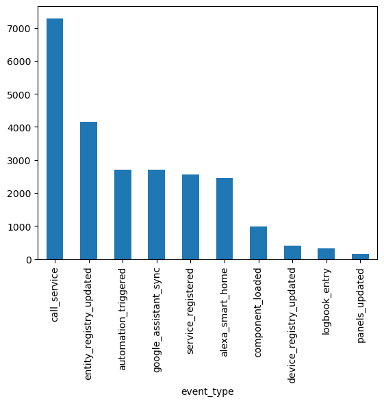

```python
type_plot = event_types_count.sort_values(ascending=False)
top10type = type_plot.head(10)

top10type

top10type.plot.bar()
```

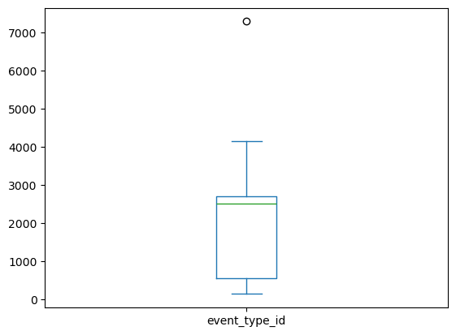

```python
top10type.plot.box()
```

```python
query = text('''
    SELECT
        et.event_type,
        COUNT(e.event_id) AS event_count
    FROM events e
    LEFT JOIN event_types et ON e.event_type_id = et.event_type_id
    GROUP BY et.event_type
    ORDER BY event_count DESC;
''')

# Execute the query and load results into a DataFrame
with engine.connect() as connection:
    event_types_df = pd.read_sql_query(query, connection)

# Display the results
event_types_df.head(40)
```

|  | event_type | event_count |
| --- | --- | --- |
| 0 | call_service | 7286 |
| 1 | entity_registry_updated | 4157 |
| 2 | google_assistant_sync | 2710 |
| 3 | automation_triggered | 2709 |
| 4 | service_registered | 2560 |
| 5 | alexa_smart_home | 2455 |
| 6 | component_loaded | 978 |
| 7 | device_registry_updated | 411 |
| 8 | logbook_entry | 334 |
| 9 | ios.became_active | 150 |
| 10 | panels_updated | 150 |
| 11 | homekit_state_change | 131 |
| 12 | ios.entered_background | 124 |
| 13 | android.zone_entered | 68 |
| 14 | ios.finished_launching | 43 |
| 15 | telegram_sent | 39 |
| 16 | repairs_issue_registry_updated | 38 |
| 17 | lovelace_updated | 24 |
| 18 | ios.zone_exited | 21 |
| 19 | ios.zone_entered | 19 |
| 20 | automation_reloaded | 15 |
| 21 | core_config_updated | 14 |
| 22 | shelly.click | 12 |
| 23 | scene_reloaded | 8 |
| 24 | event_mqtt_reloaded | 8 |
| 25 | service_removed | 8 |
| 26 | event_telegram_reloaded | 8 |
| 27 | event_template_reloaded | 8 |
| 28 | homeassistant_start | 7 |
| 29 | homeassistant_started | 7 |
| 30 | nodered | 7 |
| 31 | themes_updated | 6 |
| 32 | homeassistant_stop | 6 |
| 33 | config_entry_discovered | 5 |
| 34 | shopping_list_updated | 4 |
| 35 | android.zone_exited | 2 |

### Query 3: Analyze Events Over Time

This query counts the number of events per day.

```python
query = text('''
    SELECT
        DATE(FROM_UNIXTIME(e.time_fired_ts)) AS event_date,
        COUNT(e.event_id) AS daily_event_count
    FROM events e
    GROUP BY event_date
    ORDER BY event_date;
''')

# Execute the query and load results into a DataFrame
with engine.connect() as connection:
    daily_events_df = pd.read_sql_query(query, connection)

# Display the results
daily_events_df.head(100)
```

|  | event_date | daily_event_count |
| --- | --- | --- |
| 0 | 2025-01-28 | 2640 |
| 1 | 2025-01-29 | 3437 |
| 2 | 2025-01-30 | 1921 |
| 3 | 2025-01-31 | 922 |
| 4 | 2025-02-01 | 1490 |
| 5 | 2025-02-02 | 1492 |
| 6 | 2025-02-03 | 4056 |
| 7 | 2025-02-04 | 1721 |
| 8 | 2025-02-05 | 3473 |
| 9 | 2025-02-06 | 2913 |
| 10 | 2025-02-07 | 467 |

### Visualize Event Data

We'll plot a bar chart for event types and a time series plot for daily events.

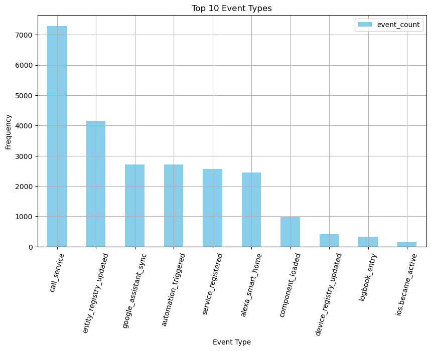

```python
import matplotlib.pyplot as plt

# Filter for the top 10 event types by frequency
top_10_event_types = event_types_df.nlargest(10, 'event_count')

# Plot the top 10 event types
top_10_event_types.plot(kind='bar', x='event_type', y='event_count', color='skyblue', figsize=(10, 6))
plt.title('Top 10 Event Types')
plt.xlabel('Event Type')
plt.ylabel('Frequency')
plt.xticks(rotation=75)
plt.grid(True)
```

[figure not shown]

```python
# Plot daily event frequency
daily_events_df.plot(x='event_date', y='daily_event_count', kind='line', figsize=(12, 6), color='orange')
plt.title('Daily Event Frequency')
plt.xlabel('Date')
plt.ylabel('Number of Events')
plt.grid(True)
plt.show()
```

```python
query = text('''
    SELECT *
    FROM states
''')

# Execute the query and load results into a DataFrame
with engine.connect() as connection:
    state_df = pd.read_sql_query(query, connection)

# Display the results
state_df.head()
```

|  | state_id | entity_id | state | attributes | event_id | last_changed | last_changed_ts | last_reported_ts | last_updated | last_updated_ts | old_state_id | attributes_id | context_id | context_user_id | context_parent_id | origin_idx | context_id_bin | context_user_id_bin | context_parent_id_bin | metadata_id |
| --- | --- | --- | --- | --- | --- | --- | --- | --- | --- | --- | --- | --- | --- | --- | --- | --- | --- | --- | --- | --- |
| 0 | 40676190 | None | living_room | None | None | None | 1.737940e+09 | 1.737940e+09 | None | 1.737940e+09 | NaN | 4215215 | None | None | None | 0 | b'\x01\x94\xa5P\xc1t:\xb5\xd0;\xbfDct\x10w' | None | None | 321 |
| 1 | 40676191 | None | 3.16 | None | None | None | NaN | 1.737940e+09 | None | 1.737940e+09 | NaN | 462685 | None | None | None | 0 | b'\x01\x94\xa5P\xc1t:\xb5\xd0;\xbfDct\x10w' | None | None | 1765 |
| 2 | 40676192 | None | 2.9 | None | None | None | NaN | 1.737940e+09 | None | 1.737940e+09 | NaN | 4168578 | None | None | None | 0 | b'\x01\x94\xa5P\xc1\xe9\\\xc6\x8f\xfehh\xc8\xe... | None | None | 3280 |
| 3 | 40676193 | None | 25.8570793932855 | None | None | None | NaN | 1.737940e+09 | None | 1.737940e+09 | NaN | 4168582 | None | None | None | 0 | b'\x01\x94\xa5P\xc1\xe9\x16^[ye\xaex\x0c\xe3\xf5' | None | None | 3281 |
| 4 | 40676194 | None | 3.7 | None | None | None | NaN | 1.737940e+09 | None | 1.737940e+09 | NaN | 4184865 | None | None | None | 0 | b'\x01\x94\xa5P\xc2\x03\xe0\xef\x1defT\t\xb3\x... | None | None | 3006 |

```python
#state_df.to_csv('states.csv', index=False)
```

```python
query = text('''
    SELECT *
    FROM states_meta

''')

# Execute the query and load results into a DataFrame
with engine.connect() as connection:
    states_meta_df = pd.read_sql_query(query, connection)

# Display the results
states_meta_df.head()
```

|  | metadata_id | entity_id |
| --- | --- | --- |
| 0 | 85 | alarm_control_panel.alarmo |
| 1 | 3274 | alarm_control_panel.gateway_alarm |
| 2 | 3276 | alarm_control_panel.gateway2_alarm |
| 3 | 385 | automation.button_master_bedroom |
| 4 | 390 | automation.ebrahim_room_bathroom_lights |

```python
#states_meta_df.to_csv('states_meta.csv', index=False)
```

```python
query = text('''
    SELECT *
    FROM state_attributes

''')

# Execute the query and load results into a DataFrame
with engine.connect() as connection:
    attributes_df = pd.read_sql_query(query, connection)

# Display the results
attributes_df.head()
```

|  | attributes_id | hash | shared_attrs |
| --- | --- | --- | --- |
| 0 | 11 | 2279692281 | {"auto_update":true,"installed_version":"5.8.0... |
| 1 | 13 | 2284275167 | {"auto_update":true,"installed_version":"0.112... |
| 2 | 16 | 4222784383 | {"auto_update":true,"installed_version":"2.4.5... |
| 3 | 17 | 2089219955 | {"auto_update":true,"installed_version":"0.13.... |
| 4 | 19 | 2385148259 | {"auto_update":true,"installed_version":"0.2.0... |

# Exploring State Changes and Attributes in Home Assistant

An IoT device or data from a service is represented as one or more entities in Home Assistant. An entity in the core is represented as a state.

Each state has an identifier for the entity in the format of `<domain>.<object_id>`, a state and attributes that further describe the state. An example of this would be `light.kitchen` with the state `on` and attributes describing the color and the brightness.

The `<domain>` part of an entity identifier is equal to the Home Assistant component that is maintaining the state. This domain can be used to figure out what kind of state attributes to expect.

## Database

All states are stored in the database in a table named `states`.

The difference between `last_changed_ts` and `last_updated_ts` is that `last_changed_ts` only updates when the `state` value was changed while `last_updated_ts` is updated on any change to the state, even if that included just attributes. Example: if a light turns on, the state changes from `off` to `on`, so both `last_updated_ts` and `last_changed_ts` will update. If a light changes color from red to blue, only the state attributes change. In this case only `last_updated_ts` will change. By distinguishing between these two values, we can easily identify how long a light has been on and how long it has been on the current color/brightness.

The `last_changed_ts` field is not stored in the database when it is the same as the `last_updated_ts` field. See Fetching the last_changed_ts when it is NULL for queries to populate the value when it is NULL.

```python
# Define the query
query = '''
SELECT *
FROM states
LIMIT 10;

'''

# Execute the query and load results into a DataFrame
with engine.connect() as connection:
    states_df = pd.read_sql_query(query, connection)

# Display the results
states_df.head()
```

|  | state_id | entity_id | state | attributes | event_id | last_changed | last_changed_ts | last_reported_ts | last_updated | last_updated_ts | old_state_id | attributes_id | context_id | context_user_id | context_parent_id | origin_idx | context_id_bin | context_user_id_bin | context_parent_id_bin | metadata_id |
| --- | --- | --- | --- | --- | --- | --- | --- | --- | --- | --- | --- | --- | --- | --- | --- | --- | --- | --- | --- | --- |
| 0 | 40676190 | None | living_room | None | None | None | 1.737940e+09 | 1.737940e+09 | None | 1.737940e+09 | None | 4215215 | None | None | None | 0 | b'\x01\x94\xa5P\xc1t:\xb5\xd0;\xbfDct\x10w' | None | None | 321 |
| 1 | 40676191 | None | 3.16 | None | None | None | NaN | 1.737940e+09 | None | 1.737940e+09 | None | 462685 | None | None | None | 0 | b'\x01\x94\xa5P\xc1t:\xb5\xd0;\xbfDct\x10w' | None | None | 1765 |
| 2 | 40676192 | None | 2.9 | None | None | None | NaN | 1.737940e+09 | None | 1.737940e+09 | None | 4168578 | None | None | None | 0 | b'\x01\x94\xa5P\xc1\xe9\\\xc6\x8f\xfehh\xc8\xe... | None | None | 3280 |
| 3 | 40676193 | None | 25.8570793932855 | None | None | None | NaN | 1.737940e+09 | None | 1.737940e+09 | None | 4168582 | None | None | None | 0 | b'\x01\x94\xa5P\xc1\xe9\x16^[ye\xaex\x0c\xe3\xf5' | None | None | 3281 |
| 4 | 40676194 | None | 3.7 | None | None | None | NaN | 1.737940e+09 | None | 1.737940e+09 | None | 4184865 | None | None | None | 0 | b'\x01\x94\xa5P\xc2\x03\xe0\xef\x1defT\t\xb3\x... | None | None | 3006 |

### Attributes

The `created` field is no longer stored in the `states` table to avoid duplicating data in the database as it was always the same as `last_updated_ts` and the matching `state_change` event's `time_fired_ts`.

As many `attributes` are the same, attributes are stored in the `state_attributes` table with many to one relationship:

```python
# Define the query
query = '''
SELECT *
FROM state_attributes
LIMIT 10;

'''

# Execute the query and load results into a DataFrame
with engine.connect() as connection:
    states_attributes_df = pd.read_sql_query(query, connection)

# Display the results
states_attributes_df.head()
```

|  | attributes_id | hash | shared_attrs |
| --- | --- | --- | --- |
| 0 | 11 | 2279692281 | {"auto_update":true,"installed_version":"5.8.0... |
| 1 | 13 | 2284275167 | {"auto_update":true,"installed_version":"0.112... |
| 2 | 16 | 4222784383 | {"auto_update":true,"installed_version":"2.4.5... |
| 3 | 17 | 2089219955 | {"auto_update":true,"installed_version":"0.13.... |
| 4 | 19 | 2385148259 | {"auto_update":true,"installed_version":"0.2.0... |

The Example queries show how to find `attributes` that were recorded after the change over.

As many `entity_id` fields are the same, `entity_id` is stored in the `states_meta` table with a many to one relationship on `metadata_id`:

```python
# Define the query
query = '''
SELECT *
FROM states_meta
LIMIT 10;

'''

# Execute the query and load results into a DataFrame
with engine.connect() as connection:
    states_meta_df = pd.read_sql_query(query, connection)

# Display the results
states_meta_df.head()
```

|  | metadata_id | entity_id |
| --- | --- | --- |
| 0 | 85 | alarm_control_panel.alarmo |
| 1 | 3274 | alarm_control_panel.gateway_alarm |
| 2 | 3276 | alarm_control_panel.gateway2_alarm |
| 3 | 385 | automation.button_master_bedroom |
| 4 | 390 | automation.ebrahim_room_bathroom_lights |

## Example queries

### Significant states

Users are usually not so interested in state updates that only changed the attributes. Attribute only changes can be triggered by a light changing color or a media player changing song (which happens every ~3 minutes!). Since `last_changed_ts` is `NULL` when it has not changed, it's easy to filter for just the states where the state was changed:

```python
# Define the query
query = '''
SELECT
    states_meta.entity_id,
    state_attributes.shared_attrs,
    states.last_updated_ts
FROM
    states
LEFT JOIN
    states_meta ON states.metadata_id = states_meta.metadata_id
LEFT JOIN
    state_attributes ON states.attributes_id = state_attributes.attributes_id
WHERE
    states.last_changed_ts IS NULL;

'''

# Execute the query and load results into a DataFrame
with engine.connect() as connection:
    states_metaex_df = pd.read_sql_query(query, connection)

# Display the results
states_metaex_df.head()
```

|  | entity_id | shared_attrs | last_updated_ts |
| --- | --- | --- | --- |
| 0 | sensor.iphone_esp32_distance_value | {"unit_of_measurement":"m","friendly_name":"iP... | 1.737940e+09 |
| 1 | sensor.nas6b2b8b_cpu_usage | {"state_class":"measurement","unit_of_measurem... | 1.737940e+09 |
| 2 | sensor.nas6b2b8b_memory_usage | {"state_class":"measurement","unit_of_measurem... | 1.737940e+09 |
| 3 | sensor.cpu_speed | {"arch":"x86_64","brand":"Intel(R) Core(TM) i5... | 1.737940e+09 |
| 4 | cover.smart_garage_door_opener_door | {"device_class":"garage","friendly_name":"Smar... | 1.737940e+09 |

### Linking a new state to an old state

After startup, once a state is changed, the id of the old state is stored as `old_state_id`, making it easy to find the previous state.

```python
# Define the query
query = '''

SELECT
    states_meta.entity_id,
    states.state_id,
    old_states.state_id,
    state_attributes.shared_attrs,
    states.last_updated_ts
FROM
    states
LEFT JOIN
    states AS old_states ON states.old_state_id = old_states.state_id
LEFT JOIN
    states_meta ON (states.metadata_id = states_meta.metadata_id)
LEFT JOIN
    state_attributes ON (states.attributes_id = state_attributes.attributes_id);


'''

# Execute the query and load results into a DataFrame
with engine.connect() as connection:
    link_new_to_old_state_df = pd.read_sql_query(query, connection)

# Display the results
link_new_to_old_state_df.head()
```

|  | entity_id | state_id | state_id | shared_attrs | last_updated_ts |
| --- | --- | --- | --- | --- | --- |
| 0 | sensor.front_r_car_count | 40896720 | NaN | {"unit_of_measurement":"objects","icon":"mdi:c... | 1.738027e+09 |
| 1 | sensor.front_r_all_count | 40896721 | NaN | {"unit_of_measurement":"objects","icon":"mdi:s... | 1.738027e+09 |
| 2 | sensor.bader_esp_iphone_distance | 40896722 | NaN | {"distance":0.39,"friendly_name":"Bader ESP iP... | 1.738027e+09 |
| 3 | sensor.espresense_master_uptime | 40896723 | NaN | {"unit_of_measurement":"s","friendly_name":"ES... | 1.738027e+09 |
| 4 | sensor.espresense_living_room_uptime | 40896724 | NaN | {"unit_of_measurement":"s","friendly_name":"ES... | 1.738027e+09 |

### Fetching attributes

Attributes are stored in the `state_attributes` table.

```python
# Define the query
query = '''

SELECT
    states.state_id,
    state_attributes.shared_attrs
FROM
    states
LEFT JOIN
    state_attributes
ON
    states.attributes_id = state_attributes.attributes_id

'''

# Execute the query and load results into a DataFrame
with engine.connect() as connection:
    fetching_attributes_df = pd.read_sql_query(query, connection)

# Display the results
fetching_attributes_df.head()
```

|  | state_id | shared_attrs |
| --- | --- | --- |
| 0 | 41250449 | {"auto_update":true,"installed_version":"5.8.0... |
| 1 | 41257939 | {"auto_update":true,"installed_version":"5.8.0... |
| 2 | 41402154 | {"auto_update":true,"installed_version":"5.8.0... |
| 3 | 41858994 | {"auto_update":true,"installed_version":"5.8.0... |
| 4 | 42194642 | {"auto_update":true,"installed_version":"5.8.0... |

Attributes can be found in the following order `state_attributes.shared_attrs` or `states.attributes`. As new states are recorded `states.attributes` will be phased out.

### Fetching the last_changed_ts when it is NULL

```python
# Define the query
query = '''

SELECT
    states_meta.entity_id,
    states.state,
    states.last_updated_ts,
    IF(
        states.last_changed_ts IS NULL,
        states.last_updated_ts,
        states.last_changed_ts
    ) AS last_changed_ts
FROM
    states
LEFT JOIN
    states_meta
ON
    (states.metadata_id = states_meta.metadata_id);

'''

# Execute the query and load results into a DataFrame
with engine.connect() as connection:
    fetching_attributes_null_df = pd.read_sql_query(query, connection)

# Display the results
fetching_attributes_null_df.head()
```

|  | entity_id | state | last_updated_ts | last_changed_ts |
| --- | --- | --- | --- | --- |
| 0 | sensor.front_r_car_count | 2 | 1.738027e+09 | 1.738027e+09 |
| 1 | sensor.front_r_all_count | 2 | 1.738027e+09 | 1.738027e+09 |
| 2 | sensor.bader_esp_iphone_distance | master | 1.738027e+09 | 1.738013e+09 |
| 3 | sensor.espresense_master_uptime | 12180 | 1.738027e+09 | 1.738027e+09 |
| 4 | sensor.espresense_living_room_uptime | 104415 | 1.738027e+09 | 1.738027e+09 |

### Viewing state data in a human readable format

```python
# Define the query
query = '''
SELECT
    states.state_id,
    states_meta.entity_id,
    from_unixtime(states.last_updated_ts) AS last_update,
    from_unixtime(if(states.last_changed_ts
    IS NULL,states.last_updated_ts,states.last_changed_ts)) AS last_changed,
    state_attributes.shared_attrs,
    hex(states.context_id_bin)
FROM
    states
LEFT JOIN
    states_meta
ON
    (states.metadata_id=states_meta.metadata_id)
LEFT JOIN
    state_attributes
ON
    (states.attributes_id=state_attributes.attributes_id)
WHERE last_changed_ts IS NULL;


'''

# Execute the query and load results into a DataFrame
with engine.connect() as connection:
    states_readable_df = pd.read_sql_query(query, connection)

# Display the results
states_readable_df.tail()
```

|  | state_id | entity_id | last_update | last_changed | shared_attrs | hex(states.context_id_bin) |
| --- | --- | --- | --- | --- | --- | --- |
| 1633685 | 43065694 | sensor.system_monitor_memory_use | 2025-02-07 11:44:15.099930 | 2025-02-07 11:44:15.099930 | {"state_class":"measurement","unit_of_measurem... | 0194DF94BF7B7DA1EF53A46E5ADA6100 |
| 1633686 | 43065695 | sensor.system_monitor_packets_out_enp0s31f6 | 2025-02-07 11:44:15.100049 | 2025-02-07 11:44:15.100049 | {"state_class":"total_increasing","friendly_na... | 0194DF94BF7C085E39A071CF8B791D71 |
| 1633687 | 43065696 | sensor.system_monitor_processor_use | 2025-02-07 11:44:15.100140 | 2025-02-07 11:44:15.100140 | {"state_class":"measurement","unit_of_measurem... | 0194DF94BF7CBB4932AD1C5ED0278CE9 |
| 1633688 | 43065697 | sensor.lounge_pir_last_seen | 2025-02-07 11:44:16.322124 | 2025-02-07 11:44:16.322124 | {"device_class":"timestamp","icon":"mdi:clock"... | 0194DF94C4423D27305EDA38C5447E68 |
| 1633689 | 43065699 | sensor.lounge_pir_illuminance | 2025-02-07 11:44:16.921451 | 2025-02-07 11:44:16.921451 | {"state_class":"measurement","unit_of_measurem... | 0194DF94C699BFA9452BE9E62D908C97 |

```python
# Display the result
display(event_states_df.head())
display(event_states_df.tail())
display(event_states_df.info())
display(event_states_df.shape)
```

|  | event_type | time_fired_ts_bahrain | data | attributes | context_id | context_parent_id_bin |
| --- | --- | --- | --- | --- | --- | --- |
| 0 | entity_registry_updated | 2025-01-28 07:12:37.002532 | {"action":"update","entity_id":"media_player.s... | None | 0194AA77AB8A77464986B5B1684ED9F4 | None |
| 1 | google_assistant_sync | 2025-01-28 07:12:59.928206 | {"request_id":"551951063036160869","source":"c... | None | 0194AA78051834903FD24377E9DE0039 | None |
| 2 | entity_registry_updated | 2025-01-28 07:17:36.997323 | {"action":"update","entity_id":"media_player.s... | None | 0194AA7C3F6505DB9423E45998F5BC98 | None |
| 3 | call_service | 2025-01-28 07:17:57.778699 | {"domain":"switch","service":"turn_on","servic... | None | 0194AA7C9091569068706C442E899912 | None |
| 4 | google_assistant_sync | 2025-01-28 07:17:58.069518 | {"request_id":"10347385357718613459","source":... | None | 0194AA7C91B532D5D9D091B679F812DE | None |

|  | event_type | time_fired_ts_bahrain | data | attributes | context_id | context_parent_id_bin |
| --- | --- | --- | --- | --- | --- | --- |
| 2190503 | state_changed | 2025-02-07 14:14:39.124820 | None | {"ip":"192.168.11.41","uptime":79755,"firm":"m... | 0194DF79A6148882557DD905CAFA17C9 | None |
| 2190504 | state_changed | 2025-02-07 14:14:39.125151 | None | {"unit_of_measurement":"s","friendly_name":"ES... | 0194DF79A615C5B50B73A9B33E12883B | None |
| 2190505 | state_changed | 2025-02-07 14:14:40.158171 | None | {"ip":"192.168.11.43","uptime":79800,"firm":"m... | 0194DF79AA1EE552EBBA6C734F9FC06B | None |
| 2190506 | state_changed | 2025-02-07 14:14:40.158711 | None | {"unit_of_measurement":"s","friendly_name":"ES... | 0194DF79AA1EF2A9F2E24CA79EF3129D | None |
| 2190507 | state_changed | 2025-02-07 14:14:40.158988 | None | {"unit_of_measurement":"bytes","friendly_name"... | 0194DF79AA1E67DD00AF6850E134086E | None |

```
<class 'pandas.core.frame.DataFrame'>
RangeIndex: 2190508 entries, 0 to 2190507
Data columns (total 6 columns):
 #   Column                 Dtype
---  ------                 -----
 0   event_type             object
 1   time_fired_ts_bahrain  datetime64[ns]
 2   data                   object
 3   attributes             object
 4   context_id             object
 5   context_parent_id_bin  object
dtypes: datetime64[ns](1), object(5)
memory usage: 100.3+ MB
```

```
None
```

```
(2190508, 6)
```